# Question:

- What factors effect survivability the most?
  - Gender?
  - Age?
  - Class?

```python
# Imports for pandas, and numpy
import numpy as np
import pandas as pd

# imports for seaborn to and matplotlib to allow graphing
import seaborn as sns
import matplotlib.pyplot as plt
get_ipython().magic(u'matplotlib inline')
%matplotlib inline

# Import function display to print out data
from IPython.display import display
```

```python
# import Titanic data CSV
titanic_reader = pd.read_csv('titanic_data.csv')
```

```python
# Remove unnecessary columns: Columns (PassengerId, Name, Ticket, Cabin, Fare, Embarked, SibSp, Parch) removed
# Create new data without unnecessary columns
titanic_data = titanic_reader.drop(['PassengerId','Name','Ticket','Cabin','Fare','Embarked', 'SibSp', 'Parch'], axis=1)
display(titanic_data.head())
# Calculate number of missing values
display(titanic_data.isnull().sum())
```

|  | Survived | Pclass | Sex | Age |
| --- | --- | --- | --- | --- |
| 0 | 0 | 3 | male | 22.0 |
| 1 | 1 | 1 | female | 38.0 |
| 2 | 1 | 3 | female | 26.0 |
| 3 | 1 | 1 | female | 35.0 |
| 4 | 0 | 3 | male | 35.0 |

```
Survived      0
Pclass        0
Sex           0
Age         177
dtype: int64
```

```python
display(titanic_data.describe())
```

|  | Survived | Pclass | Age |
| --- | --- | --- | --- |
| count | 891.000000 | 891.000000 | 714.000000 |
| mean | 0.383838 | 2.308642 | 29.699118 |
| std | 0.486592 | 0.836071 | 14.526497 |
| min | 0.000000 | 1.000000 | 0.420000 |
| 25% | 0.000000 | 2.000000 | 20.125000 |
| 50% | 0.000000 | 3.000000 | 28.000000 |
| 75% | 1.000000 | 3.000000 | 38.000000 |
| max | 1.000000 | 3.000000 | 80.000000 |

```python
# Calculate the number of males passenger
display(titanic_data[titanic_data['Sex'] == 'male'].describe())
```

|  | Survived | Pclass | Age |
| --- | --- | --- | --- |
| count | 577.000000 | 577.000000 | 453.000000 |
| mean | 0.188908 | 2.389948 | 30.726645 |
| std | 0.391775 | 0.813580 | 14.678201 |
| min | 0.000000 | 1.000000 | 0.420000 |
| 25% | 0.000000 | 2.000000 | 21.000000 |
| 50% | 0.000000 | 3.000000 | 29.000000 |
| 75% | 0.000000 | 3.000000 | 39.000000 |
| max | 1.000000 | 3.000000 | 80.000000 |

```python
# Calculate the number of females passenger
display(titanic_data[titanic_data['Sex'] == 'female'].describe())
```

|  | Survived | Pclass | Age |
| --- | --- | --- | --- |
| count | 314.000000 | 314.000000 | 261.000000 |
| mean | 0.742038 | 2.159236 | 27.915709 |
| std | 0.438211 | 0.857290 | 14.110146 |
| min | 0.000000 | 1.000000 | 0.750000 |
| 25% | 0.000000 | 1.000000 | 18.000000 |
| 50% | 1.000000 | 2.000000 | 27.000000 |
| 75% | 1.000000 | 3.000000 | 37.000000 |
| max | 1.000000 | 3.000000 | 63.000000 |

```python
# Calculate the number of survived passenger
display(titanic_data[titanic_data['Survived'] == 1].describe())
```

|  | Survived | Pclass | Age |
| --- | --- | --- | --- |
| count | 342.0 | 342.000000 | 290.000000 |
| mean | 1.0 | 1.950292 | 28.343690 |
| std | 0.0 | 0.863321 | 14.950952 |
| min | 1.0 | 1.000000 | 0.420000 |
| 25% | 1.0 | 1.000000 | 19.000000 |
| 50% | 1.0 | 2.000000 | 28.000000 |
| 75% | 1.0 | 3.000000 | 36.000000 |
| max | 1.0 | 3.000000 | 80.000000 |

```python
display(titanic_data.info())
```

```
<class 'pandas.core.frame.DataFrame'>
RangeIndex: 891 entries, 0 to 890
Data columns (total 4 columns):
Survived    891 non-null int64
Pclass      891 non-null int64
Sex         891 non-null object
Age         714 non-null float64
dtypes: float64(1), int64(2), object(1)
memory usage: 27.9+ KB
```

```
None
```

```python
display(titanic_data[titanic_data['Age'] < 18].head())
```

|  | Survived | Pclass | Sex | Age |
| --- | --- | --- | --- | --- |
| 7 | 0 | 3 | male | 2.0 |
| 9 | 1 | 2 | female | 14.0 |
| 10 | 1 | 3 | female | 4.0 |
| 14 | 0 | 3 | female | 14.0 |
| 16 | 0 | 3 | male | 2.0 |

```python
 # Function return the numbers of passengers: survived and dead
def passengers_survived():
    passengers_survived = titanic_data['Survived'].value_counts()
    # Plot: Number of survived and dead of passengers.
    plot = sns.factorplot(x='Survived', data=titanic_data, kind='count')
    plot.set_ylabels("population of passengers")
    return 'Passengers survived: %s, Passengers dead: %s.'%(passengers_survived[1], passengers_survived[0])
```

```
'Passengers survived: 342, Passengers dead: 549.'
```

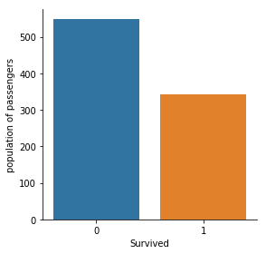

```python
display(passengers_survived())
```

Looking at survived can see: Female have more chance to survive than males on board.

# Probability of survival by class and gender. Consider this two factors effecting the survivalbility, so we need to analysis about class, gender and the relation of them.

We need to make clear:

- The number of passengers in each class?
- The number of passengers by gender?
- Gender of passengers in each class?
- The number of passengers survived by class?
- The number of passengers survivived by gender?
- The survivalbility of passengers by gender?
- Compare number of passengers survived in each class by gender.
- Survival rate of passengers by gender and class?

```python
# Function return gender of passengers: number of males and females passenger
def passengers_gender():
    menData = titanic_data[titanic_data.Sex == 'male']
    womenData = titanic_data[titanic_data.Sex == 'female']
    # Plot: Number of males and females of passengers.
    plot = sns.factorplot('Sex', data=titanic_data, kind='count')
    plot.despine(left=True)
    plot.set_ylabels("population of passengers")
    return 'Males: %s, Females: %s'%(menData.count()['Sex'], womenData.count()['Sex'])
```

```
'Males: 577, Females: 314'
```

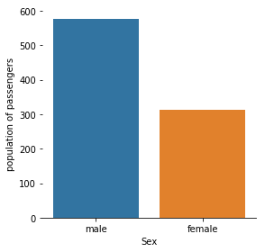

```python
display(passengers_gender())
```

Looking at the population of each gender can see: that there are a larger number of males on board than females.

```python
# Function return sex of passengers: male or female
def survived_by_gender():
    # Plot: Passengers survived by gender
    sns.set(style="darkgrid")
    plot = sns.barplot(data = titanic_data, x="Sex", y="Survived", palette="GnBu_d")
    return plot
```

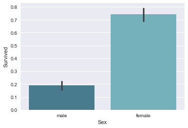

```python
display(survived_by_gender())
```

Looing at the each gender can see: Females survived have more chance to survive than males.

```python
# Function return the number of passengers survived by gender and survivalbility of passgensers by percentage.
def survivalbility():
    menData = titanic_data[titanic_data.Sex == 'male']
    womenData = titanic_data[titanic_data.Sex == 'female']
    women_survived = titanic_data[titanic_data['Survived'] == True]['Sex'] == 'female'
    men_survived = titanic_data[titanic_data['Survived'] == True]['Sex'] == 'male'
    number_women_survived = women_survived[titanic_data['Sex'] == 'female'].sum()
    number_men_survived = men_survived[titanic_data['Sex'] == 'male'].sum()
    men_survivalbility = number_men_survived/menData.count()['Sex'] * 100
    women_survivalbility = number_women_survived/womenData.count()['Sex'] * 100

    # Plot: Number of passengers survived and dead
    survived_plot = sns.factorplot('Survived', data=titanic_data, kind='count')
    survived_plot.despine(left=True)
    survived_plot.set_ylabels("population of passengers")

    # Plot: Number of passengers survived by gender
    survived_gender = sns.factorplot("Sex", "Survived", data=titanic_data, kind="bar", size=5)
    survived_gender.despine(left=True)
    survived_gender.set_ylabels("passengers survived")
    return 'Men survived: %s, women survived: %s. Men survivalbility: %s%%, Women survivalbility: %s%%'%(number_men_survived, number_women_survived, men_survivalbility, women_survivalbility)
```

```
'Men survived: 109, women survived: 233. Men survivalbility: 18.8908145581%, Women survivalbility: 74.2038216561%'
```

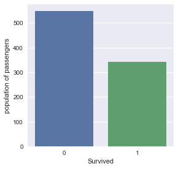

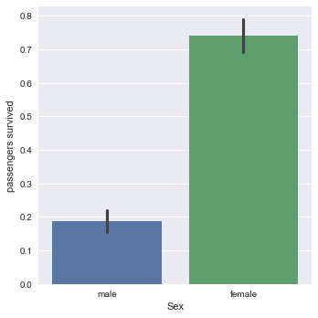

```python
display(survivalbility())
```

Looking at the each gender and survived: Comparing the survivability of the genders we see a significant survivalbility difference, about 74% of female passengers survived and only about 19% males passenger survived.

```python
# Function return passenger class: 1st, 2nd, 3rd
def number_passengers_in_class():
    data = titanic_data['Pclass'].value_counts()
    sns.set(style="darkgrid")
    # Plot: Number of passengers in each class
    plot = sns.factorplot(x='Pclass', data=titanic_data, kind='count')
    plot.set_ylabels("population of pasengers")
    return 'Passengers class: 1st: %s, 2nd: %s, 3rd: %s.' %(data[1], data[2], data[3])
```

```
'Passengers class: 1st: 216, 2nd: 184, 3rd: 491.'
```

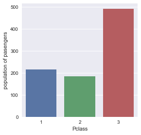

```python
display(number_passengers_in_class())
```

```python
# Function return gender of passengers by class
def gender_passenger_by_class():
    class1_data = titanic_data[titanic_data.Pclass == 1]
    class2_data = titanic_data[titanic_data.Pclass == 2]
    class3_data = titanic_data[titanic_data.Pclass == 3]
    sum_class1 = class1_data.count()['Pclass']
    sum_class2 = class2_data.count()['Pclass']
    sum_class3 = class3_data.count()['Pclass']
    # Plot: Number of passengers in each class by gender
    plot = sns.factorplot('Pclass',order=[1,2,3], data=titanic_data, hue='Sex',kind='count')
    plot.despine(left=True)
    plot.set_ylabels("population of passengers")
    return plot
```

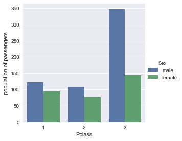

```python
gender_passenger_by_class()
```

Looking at the plot can see: Number of passengers in class 3 is higher. Males is more than females in all class.

```python
# Function compare the number of passenger survived by class and gender
def compare_survived_by_class_gender():
    # Plot: Compare number of passengers survived in each class by gender
    sns.set(style="darkgrid")
    plot = sns.barplot(data = titanic_data, x="Sex", y="Survived", hue ='Pclass', palette="GnBu_d")
    return plot
```

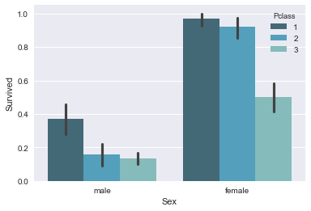

```python
display(compare_survived_by_class_gender())
```

```python
# Returns survival rate of sex and class
CLASS_1 = 1
CLASS_2 = 2
CLASS_3 = 3
def survival_rate(pclass, sex):
    grouped_by_class_sex = titanic_data.groupby(['Pclass', 'Sex']).size()[pclass,sex].astype('float')
    grouped_by_survived_sex = titanic_data.groupby(['Pclass','Survived','Sex']).size()[pclass,1,sex].astype('float')
    survived_class_sex = (grouped_by_survived_sex / grouped_by_class_sex * 100).round(2)
    return 'Class %s, %s survival rate: %s%%' %(pclass, sex, survived_class_sex)
```

```python
def get_data_group():
    # Plot: Compare number of passengers survived in each class by gender
    sns.factorplot("Pclass", "Survived", hue='Sex',order=[1,2,3], data=titanic_data, kind='point')
    plot.set_ylabels("passengers survived")
    return titanic_data.groupby(['Pclass','Survived','Sex']).size()
```

```
Pclass  Survived  Sex
1       0         female      3
                  male       77
        1         female     91
                  male       45
2       0         female      6
                  male       91
        1         female     70
                  male       17
3       0         female     72
                  male      300
        1         female     72
                  male       47
dtype: int64
```

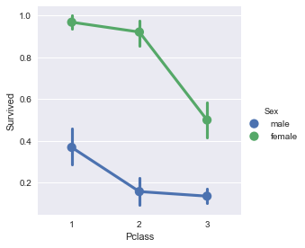

```python
display(get_data_group())
```

Survival rate decrease by class 1 -> class 2 -> class 3 in males group and females group passengers..

```python
# Display survival_rate of passenger in each class by gender
display(survival_rate(CLASS_1, 'female'))
display(survival_rate(CLASS_2, 'female'))
display(survival_rate(CLASS_3, 'female'))
display(survival_rate(CLASS_1, 'male'))
display(survival_rate(CLASS_2, 'male'))
display(survival_rate(CLASS_3, 'male'))
```

```
'Class 1, female survival rate: 96.81%'
```

```
'Class 2, female survival rate: 92.11%'
```

```
'Class 3, female survival rate: 50.0%'
```

```
'Class 1, male survival rate: 36.89%'
```

```
'Class 2, male survival rate: 15.74%'
```

```
'Class 3, male survival rate: 13.54%'
```

```python
# Plot: Grouped by class, survival and sex
def grouped_by_class_survival_sex():
    # Plot: Compare number of passengers survived in each class by gender and class
    plot = sns.factorplot(x="Sex", y="Survived", col="Pclass", data=titanic_data, saturation=.5, kind="bar", ci=None, size=5, aspect=.8)
    plot.set_ylabels("passengers survived")
    return plot
```

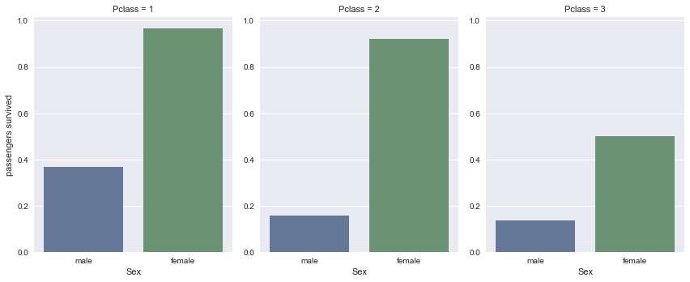

```python
grouped_by_class_survival_sex()
```

Looking at the plot can see: Females in class 1 have more chance to survive in class 2 and class 3. Males in class 1 and more chance to survive than males in class 2 and class 3. Females in class 1 survived is higher, males in class 3 dead is higher.

```python
# Plot: Number of passengers by survival, group and sex
def number_passengers_by_survival_group_sex():
    # Plot: Compare number of passengers survived in each class by gender
    plot = sns.factorplot('Survived', col='Sex', hue='Pclass', data=titanic_data, kind='count', size=7, aspect=.8)
    plot.set_ylabels("population of passengers")
    return plot
```

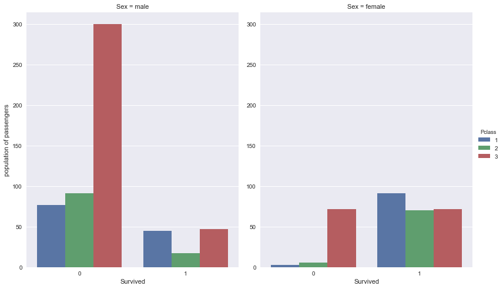

```python
number_passengers_by_survival_group_sex()
```

Looking at the plot can see: Number of females survived in class 1 is higher. Number of males and females in class 3 dead is higher.

# Age of passengers can be effectively survivalbility too. I need to analysis about factor age.

- I need to make clear:
  - How many passengers missing imfomation about age?
  - Distribution survival by age?
  - How many chidren under 18 years old survive and dead on board?
  - How many baby under 1 year old survived and dead on board?
  - The youngest, oldest and average age of passengers on board.
  - The youngest and oldest passenger to survive and dead?
  - The age of survived passengers by class and gender?

```python
# So filter age records is null, return the number passengers missing age imformation
def age_missing():
    age_record_null = pd.isnull(titanic_data['Age'])
    total_passengers_missing_age = age_record_null.sum()
    missing_age_female = titanic_data[age_record_null]['Sex'] == 'female'
    missing_age_male = titanic_data[age_record_null]['Sex'] == 'male'
    return 'Passengers age missing: %s(males: %s, females: %s)'%(total_passengers_missing_age, missing_age_male.sum(), missing_age_female.sum())
```

```python
display(age_missing())
```

```
'Passengers age missing: 177(males: 124, females: 53)'
```

```python
# Return distribution of age passenger by survived
def age_distribution_by_survival():
    # Plot: Distribution of age passenger by survived
    plot = sns.boxplot(data=titanic_data, x='Survived', y='Age')
    plot.set(title='Age Distribution by Survival',xlabel = 'Survival',ylabel = 'Age Distrobution',xticklabels = ['Died', 'Survived'])
    return plot
```

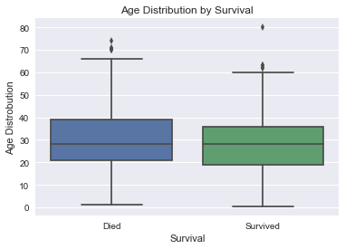

```python
age_distribution_by_survival()
```

The same between dead age group and the survived age groups. But younger passengers have more chance to survive than older passengers.

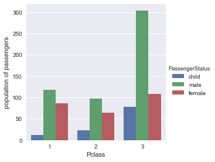

```python
# Return status of passengers
def childrenOrAdult(passenger):
     age, sex = passenger
     if age < 18:
         return 'child'
     else:
         return sex
titanic_data['PassengerStatus'] = titanic_data[['Age', 'Sex']].apply(childrenOrAdult, axis=1)
titanic_data['PassengerStatus'].value_counts()
# Plot: Passenger status: child, male or female in each class
plot = sns.factorplot('Pclass', order=[1,2,3], data=titanic_data, hue='PassengerStatus', kind='count', hue_order=['child','male','female'])
plot.despine(left=True)
plot.set_ylabels("population of passengers")
```

```python
# Return passengers under 18 years old survived and survival probability
def passengers_under_18_survived():
    less_than_18 = titanic_data[titanic_data['Age'] < 18]
    children = (less_than_18['Age'] < 18).sum()
    less_than_one = titanic_data[titanic_data['Age'] < 18]
    baby = (less_than_one['Age'] < 1).sum()
    children_under_18_survived = (titanic_data[titanic_data['Survived'] == True]['Age'] < 18).sum()
    baby_under_1_survived = (titanic_data[titanic_data['Survived'] == True]['Age'] < 1).sum()
    survival_probability = children_under_18_survived/children * 100
    return 'Passengers under 18 years old: %s(including %s baby under 1 year old), survived: %s (including %s baby under 1 year old. Survival probability is: %s%%)'%(children, baby, children_under_18_survived, baby_under_1_survived, survival_probability)
```

```python
display(passengers_under_18_survived())
```

```
'Passengers under 18 years old: 113(including 7 baby under 1 year old), survived: 61 (including 7 baby under 1 year old. Survival probability is: 53.982300885%)'
```

```python
# Return youngest and oldest passengers, average old of passengers
def yougest_oldest_passengers():
    youngestPassenger = titanic_data['Age'].min()
    oldestPassenger = titanic_data['Age'].max()
    avgPassenger = titanic_data['Age'].mean()
    return 'Youngest passenger: %s, Oldest passenger: %s, Average passenger: %s' %(youngestPassenger, oldestPassenger,avgPassenger )
```

```python
display(yougest_oldest_passengers())
```

```
'Youngest passenger: 0.42, Oldest passenger: 80.0, Average passenger: 29.6991176471'
```

```python
# Return youngest passengers to survived and dead
def youngest_survived_and_dead():
    youngest_survived = titanic_data[titanic_data['Survived'] == True]['Age'].min()
    youngest_die = titanic_data[titanic_data['Survived'] == False]['Age'].min()
    return 'Youngest to survived: %s year old, Youngest to die: %s year old' %(youngest_survived, youngest_die)
```

```python
display(youngest_survived_and_dead())
```

```
'Youngest to survived: 0.42 year old, Youngest to die: 1.0 year old'
```

```python
# Return oldest passengers to survived and dead
def oldest_survived_and_dead():
    oldest_survived = titanic_data[titanic_data['Survived'] == True]['Age'].max()
    oldest_die = titanic_data[titanic_data['Survived'] == False]['Age'].max()
    return 'Oldest to survive: %s years old, Oldest to die: %s years old' %(oldest_survived, oldest_die)
```

```python
display(oldest_survived_and_dead())
```

```
'Oldest to survive: 80.0 years old, Oldest to die: 74.0 years old'
```

```python
# Plot: Age survived by class
def age_by_class_survival():
    # Plot: Distribution passengers age by class and survived
    plot = sns.boxplot(data = titanic_data.dropna(subset = ['Age']).sort_values('Pclass'), x='Pclass', y='Age', hue='Survived')
    plot.set(title='Age by Class and Survival - Box Plot', xlabel='Pclass')
    plot.legend(bbox_to_anchor=(1.05, .7), loc=2, title = 'Survived',borderaxespad=0.)
    return plot
```

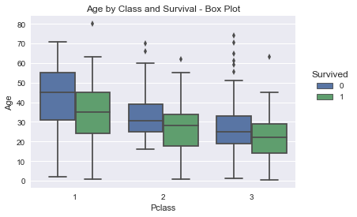

```python
age_by_class_survival()
```

Looking at each class we can see: younger passengers more chance to survive than older aged passengers on every class.

```python
# Plot: Survived age by gender
def age_by_gender_survival():
    # Plot: Distribution passengers age by gender and survived
    plot = sns.boxplot(data=titanic_data.dropna(subset = ['Age']), x= 'Sex', y= 'Age', hue='Survived')
    plot.set(title='Age by Gender and Survival')
    plot.legend(bbox_to_anchor=(1.05, .7), loc=2, title = 'Survived(0 = "Dead", 1 = "Survived")',borderaxespad=0.)
    return plot
```

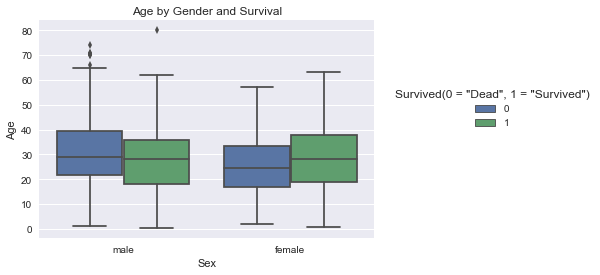

```python
age_by_gender_survival()
```

- Looking at the plot we see comparing between the genders : males older survived lower than younger males.
- Females older survived more than younger females.

# Conclusion:

1. About missing data in the Age column:
   - Looking at Age column can be see: 714/891 elements not null. So we have 177 passengers that are not accounted that could affect the graphs that were created age distribution such as "Distribution of age in passengers".
   - In the graph "Age survived by class" and "Age survived by gender" can be affected by 177 ages null elements that wasn't in the data: 177 passengers can be younger or older ages than what was determined when calculating the 714 ages that existed in the age column.
2. Age effect of survivability
   - Age can very well effect a chance of survivability, younger ages have more chance to survive than passengers of older age. Children under 18 years old survived about above 50 percent, baby under 1 year old all survived.
3. Gender and class effect of survivalbility
   - Survival rate: about 74% females survived and 19% males survived. Number of females survived in class 1 is higher. Number of males and females in class 3 dead is higher.
   - Survivalbility: Men survived: 109/577, women survived: 233/314.
   - Therefor females have more chance to survive than males. Passengers in class 1 have more chance to survive than passengers in class 2 and class 3. => Gender and class are the most factors effect to survivability of passengers on board.